# Weight-for-age Z-score in Bangladeshi infants aged 6-13 months

Dataset 7: Bangladesh growth monitoring and promotion survey

RSR feasibility analysis

2026-08-03

# Introduction

The data come from a cross-sectional household survey in rural Bangladesh that compared two ways of delivering growth monitoring and promotion (GMP): sessions held at a community clinic (“facility-based”) and sessions held in the community/home (“home-based”). Caregivers of 3038 young children across six upazilas were interviewed and the children were weighed and measured (source paper: PLOS ONE, e0324918). Weight-for-age Z-score (WAZ) is the composite index that growth-monitoring programmes actually plot on the child’s card, so it is the anthropometric outcome most directly tied to what GMP does; it blends acute and chronic deficits and is the standard trigger for referral.

**Aim.** Among rural Bangladeshi infants aged 6-13 months, we examined which of GMP delivery model, child sex, child age, mother’s age, mother’s schooling, household asset tertile, NGO membership and toilet quality are independently associated with weight-for-age Z-score, mutually adjusting for the others.

This is a *Purpose 3* analysis: several predictors are of interest and the question is which remain associated with the outcome after mutual adjustment.

# Methods

**Data source.** Cross-sectional survey of 3038 caregiver-child pairs in six rural upazilas of Bangladesh. The study sampled 60 community-clinic catchment areas, arranged as matched pairs, one area of each pair receiving facility-based and the other home-based GMP. The file supplied for this catalogue contains one row per child.

**Variables.** The outcome is `weight_for_age_z`, the WHO weight-for-age Z-score in standard-deviation units; more negative values mean lighter children for their age. Predictors are: GMP delivery model (facility-based = reference, home-based); child sex (male = reference); child age in months (continuous, observed range 6.0 to 13.0); mother’s age in years (continuous); mother’s completed schooling in years (continuous); household asset index tertile (lowest = reference, middle, highest); NGO membership (no = reference); and improved toilet facility (no = reference).

*Delivery model versus sub-district.* `delivery_model` and `sub_district` are almost the same variable: only 8 of 3038 records (0.3%) sit in a sub-district whose other children received the alternative model. Fitting both together produces variance inflation factors of roughly 96 and 103 and a delivery-model standard error about nine times larger than it should be, with the coefficient flipping sign. We therefore kept `delivery_model`, the substantive programme exposure the survey was designed around, and excluded `sub_district`. The consequence is that genuine geographic differences between the six upazilas are absorbed into the delivery-model coefficient.

*Near-constant variables dropped.* `mother_occupation` is 97.5% “housewife” and `religion_muslim` is 97.8% Muslim. Both were left out of the main model because estimates resting on 60-80 people are unstable; a sensitivity fit that puts them back is shown in the feasibility notes.

*Other Z-scores excluded.* `height_for_age_z` and `weight_for_height_z` are not predictors here. Weight-for-age is arithmetically built from the same weight measurement as weight-for-height and from the same child as height-for-age; regressing one on another tests an anthropometric identity, not a research question.

**Statistical analysis.** Linear regression via `lm()`, justified because the outcome is a continuous, approximately symmetric Z-score. We fitted a univariable model for each predictor first, then a single multivariable model containing all of them. Predictors were chosen in advance on subject-matter grounds, not by significance. Significance threshold 0.05; estimates are reported with 95% confidence intervals. Assumptions were checked with `performance::check_model()`. Analysis used R version 4.6.0 (2026-04-24) with tidyverse, gtsummary and performance.

**Missing data.** Complete-case analysis: 3033 of 3038 rows were analysed (5 dropped). Missingness is negligible, so complete-case analysis introduces no meaningful selection.

# Results

## Sample characteristics

**Table 1. Sample characteristics.**

| **Characteristic** | **N** | **N = 3,033**<sup>1</sup> |
| --- | --- | --- |
| Weight-for-age Z-score | 3,033 | -1.11 (-1.81, -0.36) |
| Growth-monitoring delivery model | 3,033 |  |
| Facility-based |  | 1,518 (50%) |
| Home-based |  | 1,515 (50%) |
| Child's sex | 3,033 |  |
| Male |  | 1,546 (51%) |
| Female |  | 1,487 (49%) |
| Child's age (months) | 3,033 | 9.70 (8.50, 11.30) |
| Mother's age (years) | 3,033 | 25.0 (21.0, 30.0) |
| Mother's schooling (years) | 3,033 | 6.0 (4.0, 9.0) |
| Household asset index tertile | 3,033 |  |
| Lowest |  | 1,022 (34%) |
| Middle |  | 1,018 (34%) |
| Highest |  | 993 (33%) |
| Mother is an NGO member | 3,033 | 1,567 (52%) |
| Improved toilet facility | 3,033 | 2,832 (93%) |

<sup>1</sup> Median (Q1, Q3); n (%)

Mothers are young (median age around 25) with a median of six years of schooling, and just over half belong to an NGO. Median weight-for-age Z-score is -1.11, about 1.1 SD below the WHO reference median, and 20.5% of children fall at or below the -2 underweight threshold.

## Exploratory figure

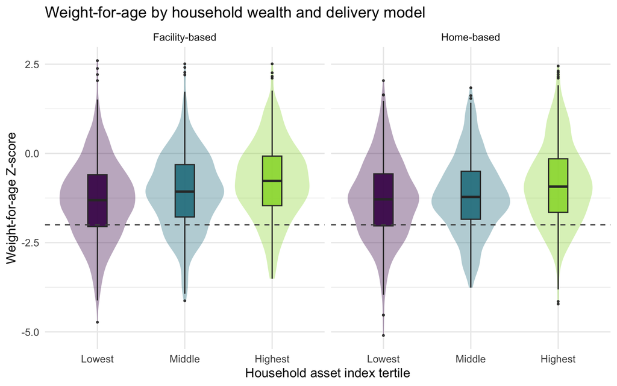

Figure 1. Distribution of weight-for-age Z-score by household asset tertile, separately for the two growth-monitoring delivery models. Boxes show medians and interquartile ranges; the dashed line marks the -2 underweight threshold.

Weight-for-age improves monotonically across asset tertiles, and the wealth gradient looks much the same in facility-based and home-based areas, which is an early hint that the delivery model itself is not doing much.

## Univariable models

| **Characteristic** | **N** | **Beta** | **95% CI** | **p-value** |
| --- | --- | --- | --- | --- |
| Growth-monitoring delivery model | 3,033 |  |  |  |
| Facility-based |  | — | — |  |
| Home-based |  | -0.02 | -0.10, 0.06 | 0.6 |
| Child's sex | 3,033 |  |  |  |
| Male |  | — | — |  |
| Female |  | 0.04 | -0.04, 0.12 | 0.3 |
| Child's age (months) | 3,033 | -0.07 | -0.09, -0.04 | <0.001 |
| Mother's age (years) | 3,033 | -0.02 | -0.02, -0.01 | <0.001 |
| Mother's schooling (years) | 3,033 | 0.06 | 0.05, 0.08 | <0.001 |
| Household asset index tertile | 3,033 |  |  |  |
| Lowest |  | — | — |  |
| Middle |  | 0.17 | 0.07, 0.26 | <0.001 |
| Highest |  | 0.48 | 0.38, 0.57 | <0.001 |
| Mother is an NGO member | 3,033 |  |  |  |
| No |  | — | — |  |
| Yes |  | -0.08 | -0.16, 0.00 | 0.051 |
| Improved toilet facility | 3,033 |  |  |  |
| No |  | — | — |  |
| Yes |  | 0.18 | 0.02, 0.34 | 0.024 |

Abbreviation: CI = Confidence Interval

Unadjusted, household wealth is the strongest correlate: children in the highest asset tertile score 0.478 (95% CI 0.383 to 0.573) Z-units above those in the lowest (p < 0.001), with the middle tertile intermediate at 0.167 (95% CI 0.072 to 0.262) (p < 0.001). Each additional year of maternal schooling is associated with a 0.065 (95% CI 0.054 to 0.076) higher Z-score (p < 0.001). Weight-for-age falls with age (-0.067 (95% CI -0.089 to -0.044) per month, p < 0.001) and with mother’s age (-0.015 (95% CI -0.022 to -0.008) per year, p < 0.001). Households with an improved toilet score 0.182 (95% CI 0.023 to 0.341) higher (p = 0.024). Neither delivery model (-0.021 (95% CI -0.100 to 0.058), p = 0.595) nor child sex (0.040 (95% CI -0.039 to 0.119), p = 0.316) is significant crude.

## Why adjustment is needed

Several of these crude associations are proxies for one another. **Household asset tertile** confounds nearly everything socio-economic in this dataset: it predicts whether a mother went to school, whether the household has a latrine, and whether the child has enough food, so both the maternal-schooling slope and the sanitation coefficient are partly wealth in disguise. **Improved toilet facility** is the sharpest example — 93% coverage overall but concentrated in the upper tertiles, and poor sanitation genuinely causes the diarrhoeal disease and environmental enteropathy that suppress weight gain, so without adjustment we cannot tell wealth from sanitation. **Mother’s age** is a third confounded variable: schooling has expanded across cohorts in Bangladesh, so older mothers have less education and, separately, higher parity; the crude negative maternal-age slope may be entirely a schooling effect. **NGO membership** is similar — microcredit and women’s-group membership tracks both household resources and maternal education. Finally, **child age** must be held constant because Z-scores decline over the observed 6-13-month window, so age differences between comparison groups would otherwise contaminate every other estimate.

## Multivariable model

| **Characteristic** | **Beta** | **95% CI** | **p-value** |
| --- | --- | --- | --- |
| Growth-monitoring delivery model |  |  |  |
| Facility-based | — | — |  |
| Home-based | -0.03 | -0.11, 0.06 | 0.5 |
| Child's sex |  |  |  |
| Male | — | — |  |
| Female | 0.04 | -0.04, 0.11 | 0.3 |
| Child's age (months) | -0.07 | -0.09, -0.05 | <0.001 |
| Mother's age (years) | 0.00 | -0.01, 0.00 | 0.2 |
| Mother's schooling (years) | 0.05 | 0.04, 0.06 | <0.001 |
| Household asset index tertile |  |  |  |
| Lowest | — | — |  |
| Middle | 0.11 | 0.01, 0.20 | 0.026 |
| Highest | 0.34 | 0.24, 0.44 | <0.001 |
| Mother is an NGO member |  |  |  |
| No | — | — |  |
| Yes | -0.02 | -0.10, 0.06 | 0.7 |
| Improved toilet facility |  |  |  |
| No | — | — |  |
| Yes | -0.03 | -0.19, 0.12 | 0.7 |

Abbreviation: CI = Confidence Interval

Model fit

| Statistic | Value |
| --- | --- |
| R-squared | 0.0713 |
| Adjusted R-squared | 0.0685 |
| Residual SE | 1.070 |
| Observations | 3,033 |
| Model parameters (excl. intercept) | 9 |

The model explains 7.1% of the variance in weight-for-age (adjusted R-squared 0.069). Holding the other predictors constant, children in the highest asset tertile score 0.336 (95% CI 0.235 to 0.436) above the lowest (p < 0.001) and children in the middle tertile 0.107 (95% CI 0.013 to 0.201) (p = 0.026). Each extra year of maternal schooling is associated with a 0.051 (95% CI 0.039 to 0.063) higher Z-score (p < 0.001), and each additional month of age with -0.069 (95% CI -0.090 to -0.047) (p < 0.001). Adjusted for household circumstances, children in home-based GMP areas score -0.026 (95% CI -0.107 to 0.055) relative to facility-based areas (p = 0.533) — an interval that comfortably includes zero.

## Unadjusted versus adjusted

**Table 2. Unadjusted and adjusted estimates.**

| **Characteristic** | **Unadjusted** **N** | **Unadjusted** **Beta** | **Unadjusted** **95% CI** | **Unadjusted** **p-value** | **Adjusted** **Beta** | **Adjusted** **95% CI** | **Adjusted** **p-value** |
| --- | --- | --- | --- | --- | --- | --- | --- |
| Growth-monitoring delivery model | 3,033 |  |  |  |  |  |  |
| Facility-based |  | — | — |  | — | — |  |
| Home-based |  | -0.02 | -0.10, 0.06 | 0.6 | -0.03 | -0.11, 0.06 | 0.5 |
| Child's sex | 3,033 |  |  |  |  |  |  |
| Male |  | — | — |  | — | — |  |
| Female |  | 0.04 | -0.04, 0.12 | 0.3 | 0.04 | -0.04, 0.11 | 0.3 |
| Child's age (months) | 3,033 | -0.07 | -0.09, -0.04 | <0.001 | -0.07 | -0.09, -0.05 | <0.001 |
| Mother's age (years) | 3,033 | -0.02 | -0.02, -0.01 | <0.001 | 0.00 | -0.01, 0.00 | 0.2 |
| Mother's schooling (years) | 3,033 | 0.06 | 0.05, 0.08 | <0.001 | 0.05 | 0.04, 0.06 | <0.001 |
| Household asset index tertile | 3,033 |  |  |  |  |  |  |
| Lowest |  | — | — |  | — | — |  |
| Middle |  | 0.17 | 0.07, 0.26 | <0.001 | 0.11 | 0.01, 0.20 | 0.026 |
| Highest |  | 0.48 | 0.38, 0.57 | <0.001 | 0.34 | 0.24, 0.44 | <0.001 |
| Mother is an NGO member | 3,033 |  |  |  |  |  |  |
| No |  | — | — |  | — | — |  |
| Yes |  | -0.08 | -0.16, 0.00 | 0.051 | -0.02 | -0.10, 0.06 | 0.7 |
| Improved toilet facility | 3,033 |  |  |  |  |  |  |
| No |  | — | — |  | — | — |  |
| Yes |  | 0.18 | 0.02, 0.34 | 0.024 | -0.03 | -0.19, 0.12 | 0.7 |

Abbreviation: CI = Confidence Interval

## Diagnostics

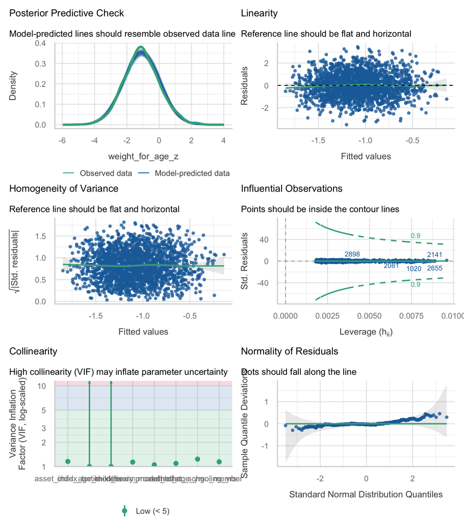

Variance inflation factors

| Term | VIF |
| --- | --- |
| delivery_model | 1.14 |
| child_sex | 1.00 |
| child_age_months | 1.00 |
| mother_age_yrs | 1.10 |
| mother_schooling_yrs | 1.24 |
| asset_index_tertile | 1.16 |
| ngo_member | 1.15 |
| improved_toilet | 1.05 |

# Discussion

Among rural Bangladeshi infants aged 6-13 months, weight-for-age is patterned by household wealth and maternal education, and not by how growth monitoring was delivered. After mutual adjustment, only asset tertile, maternal schooling and child age retain independent associations; sanitation, maternal age and NGO membership turn out to be socio-economic proxies. Practically, this says that reorganising where GMP sessions are held is not visible in children’s weight-for-age in this cross-section, whereas the household’s material and educational resources are.

**Limitations.**

*The outcome distribution is truncated by design.* The source paper states that children with severe stunting, wasting or underweight were excluded on ethical grounds so that they could be referred for treatment. The shipped file nonetheless contains 119 children with weight-for-age below -3 and 203 with height-for-age below -3, so the stated exclusion was either incomplete or applied differently in practice. Either way the lower tail of weight-for-age has been interfered with: the 20.5% underweight prevalence observed here understates the true burden, and coefficients describing how predictors shift children into the lowest part of the distribution are attenuated toward the null. This is a documented contradiction in the source, not something we could repair.

*Clustering cannot be modelled.* Delivery model is an **area-level** exposure assigned to whole upazilas — six of them — and the survey sampled 60 community-clinic catchment areas as matched pairs. Children in the same catchment share fieldworkers, clinics, markets and water sources, so their weights are correlated. The file has no clinic or cluster identifier, so no random effect or cluster-robust standard error can be fitted. The confidence interval on `delivery_model` is therefore too narrow and its p-value should not be read at face value. `sub_district` cannot serve as a substitute cluster variable because it is collinear with the exposure itself.

*Age definition is inconsistent in the source.* The paper’s abstract says children “under one year”, its methods say 6-23 months, and the data run 6.0 to 13.0 months. We describe the observed range. The narrow seven-month span also limits how much age-related decline in weight-for-age can be detected.

*Design and residual confounding.* Cross-sectional data give associations, not effects. Birth weight, gestational age, maternal height and BMI, breastfeeding and complementary feeding practice, and recent diarrhoeal or febrile illness are all absent and all cause low weight-for-age. Adjusted R-squared of 0.069 makes the extent of unexplained variation plain.

*Sparse and dropped variables.* `mother_occupation` and `religion_muslim` were excluded as near-constant, so nothing can be concluded about either.

**Future work.** A longitudinal design with cluster identifiers, birth weight and feeding data, and without the severe-malnutrition exclusion, would be required to say anything causal about GMP delivery and child weight.

# Feasibility notes

*Not part of a student report.*

**Verdict: usable, essentially as good as height-for-age.** The model fits without complaint and the crude-versus-adjusted comparison is rich — a sign reversal, two significance losses and a 30% attenuation.

What a student will hit:

1. **`delivery_model` versus `sub_district`.** 99.7% overlap (8 discordant records out of 3038). Putting both in gives VIFs around 96-103 and a nonsense delivery coefficient. The brief must force a choice.
2. **Do not put other anthropometry on the right-hand side.** `weight_for_height_z` shares the identical weight measurement with the outcome; `height_for_age_z` and `stunted` share the same height measurement and child. A student who adds `weight_for_height_z` will get an R-squared above 0.7 and think they have found something. They have found arithmetic. Also note that any derived `underweight` indicator is exactly `weight_for_age_z <= -2` and must never be a predictor here.
3. **The adjustment narrative is strong.** Improved toilet flips from 0.182 (95% CI 0.023 to 0.341) to -0.034 (95% CI -0.191 to 0.123); NGO membership goes from p = 0.05 to p = 0.69; assets attenuate 30%. This is the best “what changed after adjustment” material in the dataset alongside height-for-age.
4. **Near-constant predictors.** Sensitivity fit adding them back:

Near-constant predictors, added back

n = 77 non-housewives, 66 non-Muslim households

| term | estimate | conf.low | conf.high | p.value |
| --- | --- | --- | --- | --- |
| mother_occupationOther | -0.224 | -0.472 | 0.024 | 0.077 |
| religion_muslimMuslim | -0.339 | -0.600 | -0.078 | 0.011 |

Wide intervals resting on tiny comparison groups. Included only to justify dropping them.

5. **Low R-squared.** 0.071. Pre-empt the “my model is bad” reaction: this is normal for individual anthropometry and the assignment is about adjustment, not prediction.
6. **Overlap with the `underweight` analysis.** A student choosing between `weight_for_age_z` and `underweight` should be told they are the same question at different resolutions, and that the continuous version has more power and a cleaner diagnostic story.